# Bakeoff Example

2025-09-15

We will demonstrate using data from “The Great British Bake Off” compiled by Allison Hill in the R package `bakeoff`. The graphics that follow (and the code to produce the graphics) were lightly adapted from Allison’s Plot Twist talk.

First, let’s decide on some questions we can address with this data.

- How did viewership change as new series came out?
- The show moved channels after Series 7. Was viewership higher, lower, or about the same before and after the move?

These questions have implicitly defined our observations: they are individual units of the most granular populations we are trying to describe or compare. Here, the populations to be compared are series, and units within them are episodes. The variables now fall into place: they are measured attributes of our observations (episodes): episode number, viewership, series membership, etc. This means that the following representation of viewership data is tidy for the “change in viewership over series” analysis:

```r
# install.packages("bakeoff") #uncomment if not yet installed
library(bakeoff)
library(tidyverse)

ratings_tbl1 <- ratings %>% #save output to new tibble called ratings_tbl1
  mutate(ep_id = row_number()) %>% # create variable for episode number
  select(ep_id, viewers_7day, series, episode) #select specific columns

head(ratings_tbl1) #view first few rows of tibble
```

```
## # A tibble: 6 × 4
##   ep_id viewers_7day series episode
##   <int>        <dbl>  <dbl>   <dbl>
## 1     1         2.24      1       1
## 2     2         3         1       2
## 3     3         3         1       3
## 4     4         2.6       1       4
## 5     5         3.03      1       5
## 6     6         2.75      1       6
```

Every row is an observation (a unique episode), and the columns are variables (episode number across series, 7-day viewership, series, and episode number within series).

This is a typical example where the tidy format makes it easy to do our analysis. For example, to investigate these questions, we might make a bar plot of the number of viewers in millions within a 7-day window per episode, coloured by series. The following code uses the tidy tibble ratings_tbl1 to make this bar plot. Notice that it was easy to use our graphing environment of choice (ggplot2 in the tidyverse) to make the plot because our data is tidy, and the tidyverse is designed to work with tidy data.

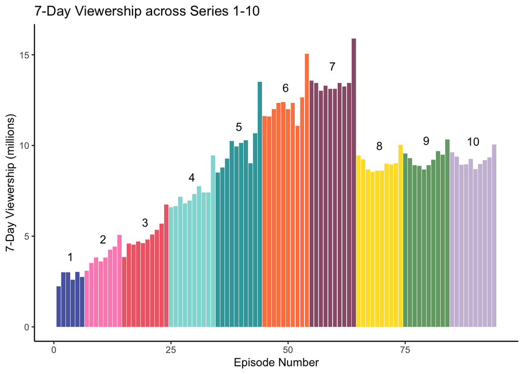

```r
series_labels <- ratings_tbl1 %>% #save output to series_labels
  mutate(series=as.factor(series)) %>% #ensure series variable is a factor (categorical variable)
  group_by(series) %>% #group by series
  summarize(y_position = median(viewers_7day) + 1, # calculate positions for the bar charts
            x_position = mean(ep_id)) #

# make the plot
ratings_tbl1 %>%
  mutate(series=as.factor(series)) %>% # ensure series is a factor variable
  ggplot(aes(x = ep_id, y = viewers_7day, fill = series)) + #set x and y axes, tell ggplot that we want things coloured by series
    geom_col(alpha = .9) + #tell ggplot we want a boxplot, change translucency with alpha
    ggtitle("7-Day Viewership across Series 1-10") + #add a title
    geom_text(data = series_labels, aes(label = series, #add text for series numbers
                                      x = x_position,
                                      y = y_position)) +
    theme_classic() +  #add a classic theme
    scale_fill_manual(values = bakeoff_palette(),
                    guide = "none") + #set the colours so they aren't rainbow
    xlab("Episode Number") +  #add x axis label
    ylab("7-Day Viewership (millions)") #add y axis label
```

Now let’s consider a different set of questions:

- How did viewership grow between premiere to final episode in each series?
- Does the premiere-to-final-episode growth vary across series?